# Supplement of dplyr & ggplot2

George Chao  
April, 2015 @ DSP A1 coures  
Contact me｜ [Data Analyst Training Program @ DSP](https://dsp.im/events/a1-basic-data-analysis-course-2/)

### mutate: 創建新變數有車機率

```r
df1 <- mutate(ubike, rate.sbi = mean(avg.sbi)/tot)
```

透過創建感興趣的變數，做進一步描述，得到**有車機率**可以進一步分析各地區情況。

### Ex1 - 學習定義新變數

- 是否為工作日(平日/假日)
- 是否下雨(晴天/雨天)

### Ex2 - 統計各行政區測站數與總車輛數

可以嘗試利用下列指令建立出下表  
- **`group_by`、`summarise`、`n_distinct`、`sum`、`filter`**

```
Source: local data frame [19 x 3]

    sarea n_distinct(sna) sum(tot)
1  三重區               5      248
2  中和區               3      180
3  中山區              19      846
4  中正區              17      774
5  信義區              23     1266
6  內湖區              11      452
7  北投區              12      612
8  南港區              11      382
9  士林區              12      520
10 大同區              10      394
11 大安區              27     1298
12 文山區              11      512
13 新店區               7      290
14 新莊區               7      312
15 松山區              15      688
16 永和區               7      338
17 汐止區               9      450
18 萬華區              12      488
19 蘆洲區               3      186
```

由上表可以觀察到**大安區** 為台北市最多測站所屬行政區  
而相對應的也是最多車輛所屬區域，進一步可以思考是否也是所需車量之人口最多的地區?  
此時會關心在有車機率整體下，是否個測站車輛配置都良好？

### boxplot: 描述各地區有車機率

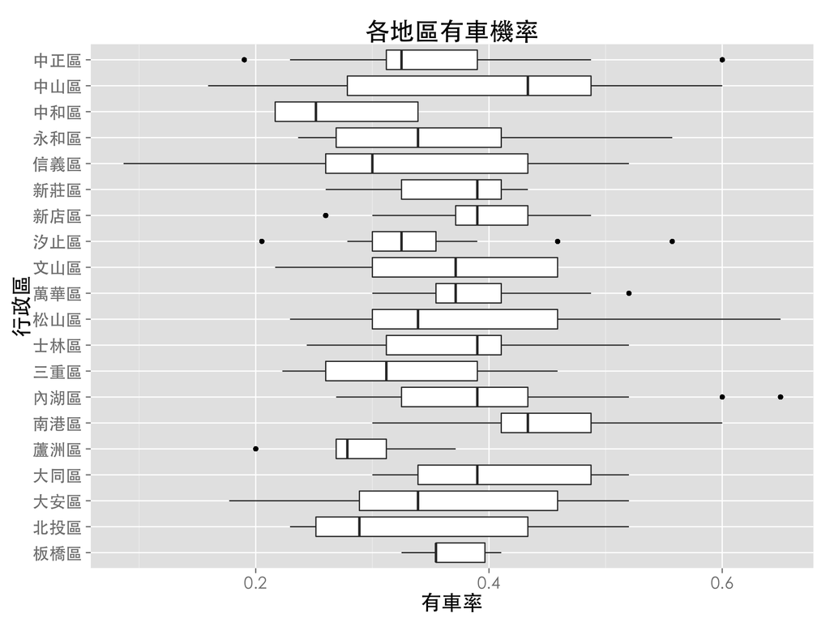

```r
thm <- function() {
  theme_gray(base_family = "STHeiti") +
  theme(text=element_text(size=18))
}

ggplot(df1, aes(x = sarea, y = rate.sbi)) +
  ggtitle("各地區有車機率") +
  geom_boxplot() +  # 挑選boxplot主題
  labs(x="行政區", y="有車率") + #給標籤名稱
  coord_flip()  + #將資料平放
  thm()
```

由上圖可以觀察到  
1. **南港區**跟**中山區**有車機率整體較高，推論車輛配置情況較好。  
2. **信義區** 有車機率range較大，可能原因有是人潮變動較大或車輛配置情況較差，還是否有其他因素?  
3. 嚴格說起來**中和區**跟**蘆洲區**整體有車機率較低，是車輛本身較少或屬於外圍地區騎乘者不易經過而停車?

### Ex3 - 大安區觀察資料整體外觀

試練習做出下列boxplot，並嘗試解釋你看到甚麼?

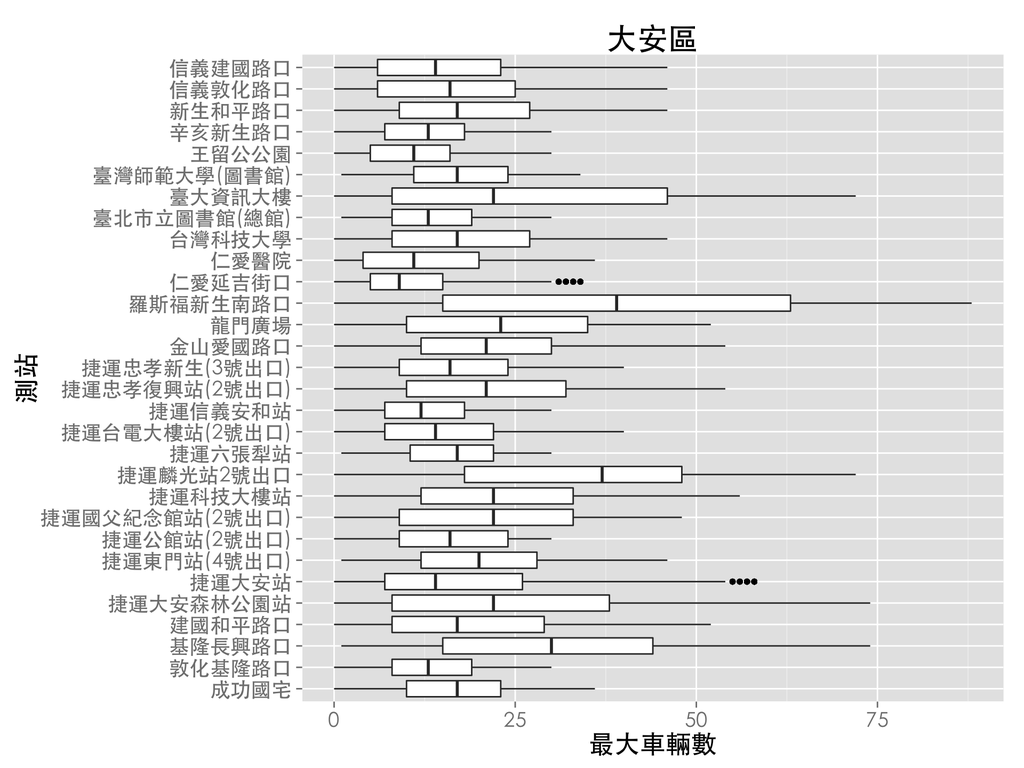